[figure not shown]

# HIV DNA and RNA (ddPCR): data quality check

Outliers, batch effects and data inconsistencies

Author

Affiliation

M Vargas, S Gianella, A Chaillon

University of California, San Diego  
Department of Medicine

Published

15 October 2026

## In short

This report checks 912 HIV DNA and RNA results from 40 participants. The samples were measured in two batches: one in 2025 and one in 2026. It looks for three kinds of problems:

1. **Data inconsistencies**: labels, dates or result codes that contradict each other.
2. **Batch effects**: results that run systematically higher or lower in one batch.
3. **Outliers**: single results that don’t fit with the participant’s other results.

### Main findings

- **Data inconsistencies:** 49 records to check (Section 2). The most important are the participants with two different samples labelled as the same visit, and a result coded as both “above the limit” and “not detected”.
- **Batch effects:** DNA: 2-LTR circles: possible shift (not confirmed at week 48 → 52) (Batch 2 reads 2.11× (1.46 to 3.06)); DNA: total HIV DNA (gag): possible shift (not confirmed at week 48 → 52) (Batch 2 reads 2.04× (1.58 to 2.63)); RNA: multiply spliced (tat/rev): likely shift (Batch 2 reads 0.52× (0.36 to 0.76)). See Section 3.
- **Outliers:** 21 results stand out compared with the same participant’s other results (Section 4).

## 1. What was measured

Table 1. Results by assay and batch. Median and range include undetected results, which are recorded as 0 (DNA) or as the detection limit (RNA).

| Assay | Batch | Participants | Samples | Detected (%) | Median | Range | Units |
| --- | --- | --- | --- | --- | --- | --- | --- |
| DNA: 2-LTR circles | Batch 1 (2025) | 39 | 116 | 45 | 0.00 | 0 to 608 | copies per 10^6 cells |
| DNA: 2-LTR circles | Batch 2 (2026) | 37 | 106 | 62 | 3.15 | 0 to 524 | copies per 10^6 cells |
| DNA: total HIV DNA (gag) | Batch 1 (2025) | 39 | 116 | 94 | 191.00 | 0 to 4310 | copies per 10^6 cells |
| DNA: total HIV DNA (gag) | Batch 2 (2026) | 37 | 106 | 99 | 348.00 | 0 to 8930 | copies per 10^6 cells |
| RNA: multiply spliced (tat/rev) | Batch 1 (2025) | 39 | 116 | 68 | 4.00 | 2.2 to 198 | copies per 1000 ng |
| RNA: multiply spliced (tat/rev) | Batch 2 (2026) | 39 | 118 | 37 | 2.20 | 2.2 to 168 | copies per 1000 ng |
| RNA: unspliced (gag) | Batch 1 (2025) | 39 | 116 | 95 | 73.00 | 2.2 to 2080 | copies per 1000 ng |
| RNA: unspliced (gag) | Batch 2 (2026) | 39 | 118 | 95 | 74.00 | 2.2 to 1720 | copies per 1000 ng |

## 2. Data inconsistencies

These are records where labels, dates or codes don’t agree.

Table 2. Summary of the data consistency checks

| Check | Records | Participants | What it probably means |
| --- | --- | --- | --- |
| Collection date doesn’t match the visit week | 14 | 6 | Visit label or collection date may be wrong. Some may be genuine late visits. |
| No result obtained | 12 | 4 | Expected for failed extractions. Check that the assay field is filled in and that each failure is listed once per assay. |
| Participant measured in one batch only | 6 | 4 | Can’t be used to compare batches. Check whether samples are missing. |
| Result codes contradict each other | 1 | 1 | A data-entry error. The code and the comment can’t both be right. |
| Results in an unusual order within one sample | 8 | 6 | Spliced RNA is normally lower than unspliced RNA. Mostly seen at very low levels, so often just noise, but worth a look. |
| Two different samples share one visit week | 8 | 4 | Probably a later visit labelled week 0 by mistake (the second sample is about a year later). The later sample is left out of Sections 3 and 4. |

**Full list of records to check (49 rows)**

| Check | File | Participant | Week | Details |
| --- | --- | --- | --- | --- |
| Collection date doesn’t match the visit week | DNA | 0082454H | 0 | Collected 288 days after the first week-0 sample (expected about 0) |
| Collection date doesn’t match the visit week | RNA | 0082454H | 0 | Collected 288 days after the first week-0 sample (expected about 0) |
| Collection date doesn’t match the visit week | DNA | 0246826L | 4 | Collected 74 days after the first week-0 sample (expected about 28) |
| Collection date doesn’t match the visit week | RNA | 0246826L | 4 | Collected 74 days after the first week-0 sample (expected about 28) |
| Collection date doesn’t match the visit week | DNA | 0246826L | 8 | Collected 106 days after the first week-0 sample (expected about 56) |
| Collection date doesn’t match the visit week | RNA | 0246826L | 8 | Collected 106 days after the first week-0 sample (expected about 56) |
| Collection date doesn’t match the visit week | DNA | 0273223D | 0 | Collected 351 days after the first week-0 sample (expected about 0) |
| Collection date doesn’t match the visit week | RNA | 0273223D | 0 | Collected 351 days after the first week-0 sample (expected about 0) |
| Collection date doesn’t match the visit week | DNA | 0273228E | 0 | Collected 323 days after the first week-0 sample (expected about 0) |
| Collection date doesn’t match the visit week | RNA | 0273228E | 0 | Collected 323 days after the first week-0 sample (expected about 0) |
| Collection date doesn’t match the visit week | DNA | 0362478J | 60 | Collected 467 days after the first week-0 sample (expected about 420) |
| Collection date doesn’t match the visit week | RNA | 0362478J | 60 | Collected 467 days after the first week-0 sample (expected about 420) |
| Collection date doesn’t match the visit week | DNA | 0781484K | 0 | Collected 384 days after the first week-0 sample (expected about 0) |
| Collection date doesn’t match the visit week | RNA | 0781484K | 0 | Collected 384 days after the first week-0 sample (expected about 0) |
| No result obtained | DNA | 0073864K | 8 | Failed DNA Extraction (listed 2 times, assay name left blank) |
| No result obtained | DNA | 0073864K | 52 | Failed DNA Extraction (listed 2 times, assay name left blank) |
| No result obtained | DNA | 0073864K | 60 | Failed DNA Extraction (listed 2 times, assay name left blank) |
| No result obtained | DNA | 0084041I | 4 | Failed DNA Extraction (listed 2 times, assay name left blank) |
| No result obtained | DNA | 0084041I | 8 | Failed DNA Extraction (listed 2 times, assay name left blank) |
| No result obtained | DNA | 0084041I | 52 | Failed DNA Extraction (listed 2 times, assay name left blank) |
| No result obtained | DNA | 0363184K | 4 | Failed DNA Extraction (listed 2 times, assay name left blank) |
| No result obtained | DNA | 0363184K | 8 | Failed DNA Extraction (listed 2 times, assay name left blank) |
| No result obtained | DNA | 0363405K | 4 | Failed DNA Extraction (listed 2 times, assay name left blank) |
| No result obtained | DNA | 0363405K | 8 | Failed DNA Extraction (listed 2 times, assay name left blank) |
| No result obtained | DNA | 0363405K | 52 | Failed DNA Extraction (listed 2 times, assay name left blank) |
| No result obtained | DNA | 0363405K | 60 | Failed DNA Extraction (listed 2 times, assay name left blank) |
| Participant measured in one batch only | DNA | 0082454H |  | Only in Batch 1 (2025) (weeks 0, 24) |
| Participant measured in one batch only | RNA | 0082454H |  | Only in Batch 1 (2025) (weeks 0, 24) |
| Participant measured in one batch only | DNA | 0246826L |  | Only in Batch 2 (2026) (weeks 0, 4, 8) |
| Participant measured in one batch only | RNA | 0246826L |  | Only in Batch 2 (2026) (weeks 0, 4, 8) |
| Participant measured in one batch only | DNA | 0363184K |  | Only in Batch 1 (2025) (weeks 0, 23, 48); the other samples failed extraction |
| Participant measured in one batch only | DNA | 0363405K |  | Only in Batch 1 (2025) (weeks 0, 24, 48); the other samples failed extraction |
| Result codes contradict each other | RNA | 0141868J | 48 | HIV_msTatRev: recorded as ‘> 2.2’ with comment ‘msTatRev NOT DETECTED’ |
| Results in an unusual order within one sample | RNA | 0073864K | 8 | Spliced RNA (12) is at least twice the unspliced RNA (2.2) |
| Results in an unusual order within one sample | RNA | 0213816J | 48 | Spliced RNA (6) is at least twice the unspliced RNA (2.2) |
| Results in an unusual order within one sample | RNA | 0214820I | 24 | Spliced RNA (34) is at least twice the unspliced RNA (14) |
| Results in an unusual order within one sample | RNA | 0781484K | 0 | Spliced RNA (14) is at least twice the unspliced RNA (4) |
| Results in an unusual order within one sample | RNA | 0781484K | 8 | Spliced RNA (14) is at least twice the unspliced RNA (4) |
| Results in an unusual order within one sample | RNA | 3034617C | 0 | Spliced RNA (10) is at least twice the unspliced RNA (4) |
| Results in an unusual order within one sample | RNA | 3034617C | 24 | Spliced RNA (10) is at least twice the unspliced RNA (4) |
| Results in an unusual order within one sample | RNA | 3034693D | 4 | Spliced RNA (8) is at least twice the unspliced RNA (4) |
| Two different samples share one visit week | DNA | 0082454H | 0 | Samples collected on 09 Aug 2022 and 24 May 2023 |
| Two different samples share one visit week | RNA | 0082454H | 0 | Samples collected on 09 Aug 2022 and 24 May 2023 |
| Two different samples share one visit week | DNA | 0273223D | 0 | Samples collected on 12 Dec 2022 and 28 Nov 2023 |
| Two different samples share one visit week | RNA | 0273223D | 0 | Samples collected on 12 Dec 2022 and 28 Nov 2023 |
| Two different samples share one visit week | DNA | 0273228E | 0 | Samples collected on 10 Nov 2023 and 22 Dec 2022 |
| Two different samples share one visit week | RNA | 0273228E | 0 | Samples collected on 10 Nov 2023 and 22 Dec 2022 |
| Two different samples share one visit week | DNA | 0781484K | 0 | Samples collected on 07 Jun 2023 and 19 May 2022 |
| Two different samples share one visit week | RNA | 0781484K | 0 | Samples collected on 07 Jun 2023 and 19 May 2022 |

## 3. Batch effects

**Figures 1 and 2** show the typical result and the share of detectable results at each visit week, with each week coloured by the batch that measured it. If there were no batch effect, the line would move smoothly from week to week. Watch for jumps where the colour changes: between weeks 0 and 4, between weeks 8 and 24, and above all between weeks 48 and 52, which are only 4 weeks apart.

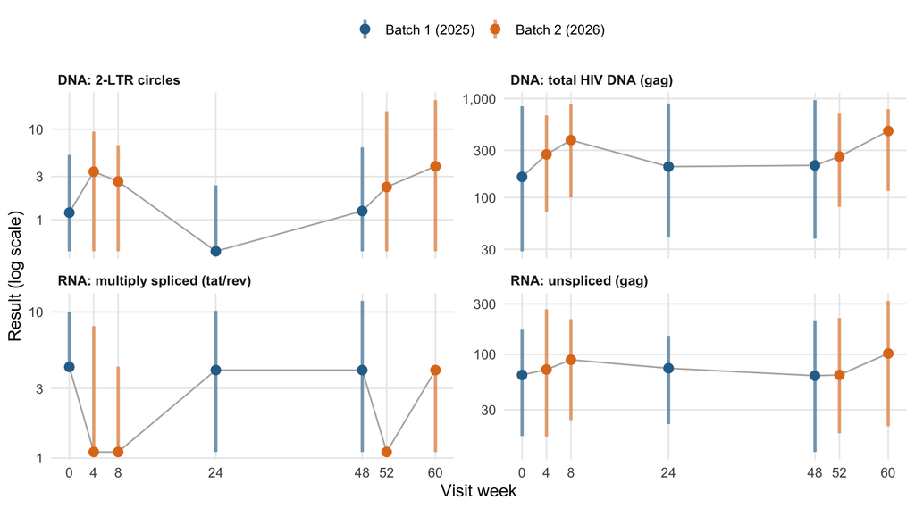

Figure 1: Median (dot) and middle half of participants (bar) at each visit, coloured by batch. Log scale; undetected results are shown at a floor value.

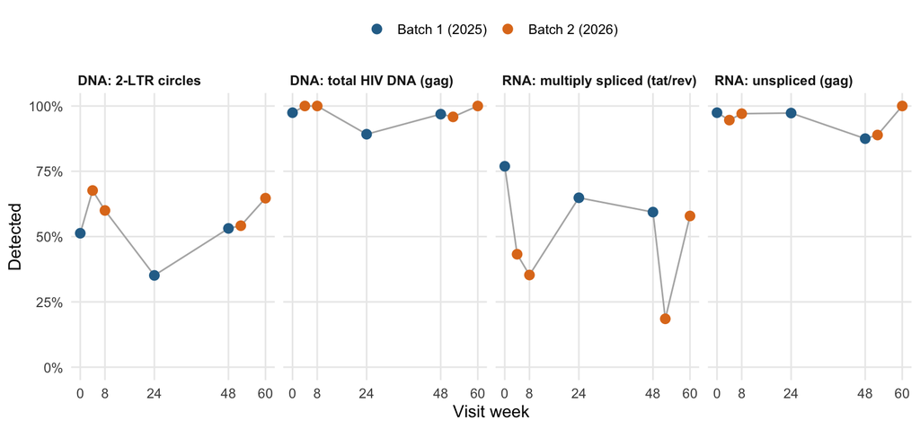

Figure 2: Share of samples with a detectable result at each visit, coloured by batch.

Table 3. Batch comparison. “Batch 2 vs Batch 1” shows how many times higher or lower the read counts are in Batch 2 for the same participant, after accounting for changes over time (95% range in brackets). The last two columns show the typical change between visits. Weeks 48 and 52 were measured in different batches, whereas weeks 24 and 48 were measured in the same batch. A larger change between weeks 48 and 52 than between weeks 24 and 48 suggests a batch effect.

| Assay | Batch 2 vs Batch 1 | Verdict | Detected B1 / B2 (%) | Week 48 → 52 (different batches) | Week 24 → 48 (same batch) |
| --- | --- | --- | --- | --- | --- |
| DNA: 2-LTR circles | 2.11× (1.46 to 3.06) | Possible shift (not confirmed at week 48 → 52) | 46 / 62 | 1.20× (n=23) | 1.00× (n=30) |
| DNA: total HIV DNA (gag) | 2.04× (1.58 to 2.63) | Possible shift (not confirmed at week 48 → 52) | 94 / 99 | 1.13× (n=23) | 0.99× (n=30) |
| RNA: multiply spliced (tat/rev) | 0.52× (0.36 to 0.76) | Likely shift | 68 / 37 | 0.31× (n=26) | 1.00× (n=30) |
| RNA: unspliced (gag) | 1.08× (0.80 to 1.46) | No clear shift | 95 / 95 | 1.28× (n=26) | 0.98× (n=30) |

**How to read this:** Check if the batch shift coincides with a jump in the proportion of detected results (Figure 2). Note that RNA results are also small, even numbers (4, 8, 14…). At these low levels, each result comes from only a few positive droplets. Small differences, such as 4 vs. 8, may simply reflect measurement noise rather than a real biological change.

**Results by run day within each batch**

| Assay | Batch | Run day | Samples | Participants | Detected (%) | Median |
| --- | --- | --- | --- | --- | --- | --- |
| DNA: 2-LTR circles | Batch 1 (2025) | 08 Oct 2025 | 20 | 7 | 45 | 0.00 |
| DNA: 2-LTR circles | Batch 1 (2025) | 14 Oct 2025 | 21 | 7 | 43 | 0.00 |
| DNA: 2-LTR circles | Batch 1 (2025) | 15 Oct 2025 | 20 | 7 | 40 | 0.00 |
| DNA: 2-LTR circles | Batch 1 (2025) | 16 Oct 2025 | 19 | 7 | 42 | 0.00 |
| DNA: 2-LTR circles | Batch 1 (2025) | 17 Oct 2025 | 20 | 7 | 60 | 7.70 |
| DNA: 2-LTR circles | Batch 1 (2025) | 22 Oct 2025 | 12 | 4 | 50 | 1.20 |
| DNA: 2-LTR circles | Batch 2 (2026) | 12 Aug 2026 | 40 | 15 | 68 | 3.85 |
| DNA: 2-LTR circles | Batch 2 (2026) | 13 Aug 2026 | 44 | 14 | 45 | 0.00 |
| DNA: 2-LTR circles | Batch 2 (2026) | 14 Aug 2026 | 22 | 8 | 86 | 6.95 |
| DNA: total HIV DNA (gag) | Batch 1 (2025) | 08 Oct 2025 | 20 | 7 | 95 | 97.00 |
| DNA: total HIV DNA (gag) | Batch 1 (2025) | 14 Oct 2025 | 21 | 7 | 100 | 164.00 |
| DNA: total HIV DNA (gag) | Batch 1 (2025) | 15 Oct 2025 | 20 | 7 | 85 | 62.10 |
| DNA: total HIV DNA (gag) | Batch 1 (2025) | 16 Oct 2025 | 19 | 7 | 100 | 230.00 |
| DNA: total HIV DNA (gag) | Batch 1 (2025) | 17 Oct 2025 | 20 | 7 | 100 | 1270.00 |
| DNA: total HIV DNA (gag) | Batch 1 (2025) | 22 Oct 2025 | 12 | 4 | 75 | 171.00 |
| DNA: total HIV DNA (gag) | Batch 2 (2026) | 12 Aug 2026 | 40 | 15 | 100 | 392.00 |
| DNA: total HIV DNA (gag) | Batch 2 (2026) | 13 Aug 2026 | 44 | 14 | 100 | 148.00 |
| DNA: total HIV DNA (gag) | Batch 2 (2026) | 14 Aug 2026 | 22 | 8 | 95 | 726.00 |
| RNA: multiply spliced (tat/rev) | Batch 1 (2025) | 13 Nov 2025 | 29 | 10 | 90 | 10.00 |
| RNA: multiply spliced (tat/rev) | Batch 1 (2025) | 14 Nov 2025 | 29 | 10 | 52 | 4.00 |
| RNA: multiply spliced (tat/rev) | Batch 1 (2025) | 25 Nov 2025 | 54 | 19 | 65 | 4.00 |
| RNA: multiply spliced (tat/rev) | Batch 2 (2026) | 30 Jul 2026 | 31 | 10 | 39 | 2.20 |
| RNA: multiply spliced (tat/rev) | Batch 2 (2026) | 04 Aug 2026 | 28 | 10 | 25 | 2.20 |
| RNA: multiply spliced (tat/rev) | Batch 2 (2026) | 05 Aug 2026 | 31 | 10 | 39 | 2.20 |
| RNA: multiply spliced (tat/rev) | Batch 2 (2026) | 07 Aug 2026 | 28 | 10 | 46 | 2.20 |
| RNA: unspliced (gag) | Batch 1 (2025) | 13 Nov 2025 | 29 | 10 | 97 | 126.00 |
| RNA: unspliced (gag) | Batch 1 (2025) | 14 Nov 2025 | 29 | 10 | 90 | 36.70 |
| RNA: unspliced (gag) | Batch 1 (2025) | 25 Nov 2025 | 54 | 19 | 96 | 73.00 |
| RNA: unspliced (gag) | Batch 2 (2026) | 30 Jul 2026 | 31 | 10 | 94 | 98.00 |
| RNA: unspliced (gag) | Batch 2 (2026) | 04 Aug 2026 | 28 | 10 | 93 | 63.00 |
| RNA: unspliced (gag) | Batch 2 (2026) | 05 Aug 2026 | 31 | 10 | 100 | 60.00 |
| RNA: unspliced (gag) | Batch 2 (2026) | 07 Aug 2026 | 28 | 10 | 93 | 117.00 |

## 4. Outliers

I looked for outliers in two ways:

- **Unusual for that participant:** a result 10 or more times higher or lower than the middle of the participant’s other results for the same assay. At least 2 other results were needed. To avoid flagging normal noise near the detection limit, a change only counts if the higher of the two values is at least 10 times the detection limit.
- **Unusual for the cohort:** a detected result far outside the range of everyone else, using a standard “far out” rule (more than 3 interquartile ranges beyond the middle half, on a log scale).

**Figure 3** shows each participant’s results over time. Flagged results are marked in red.

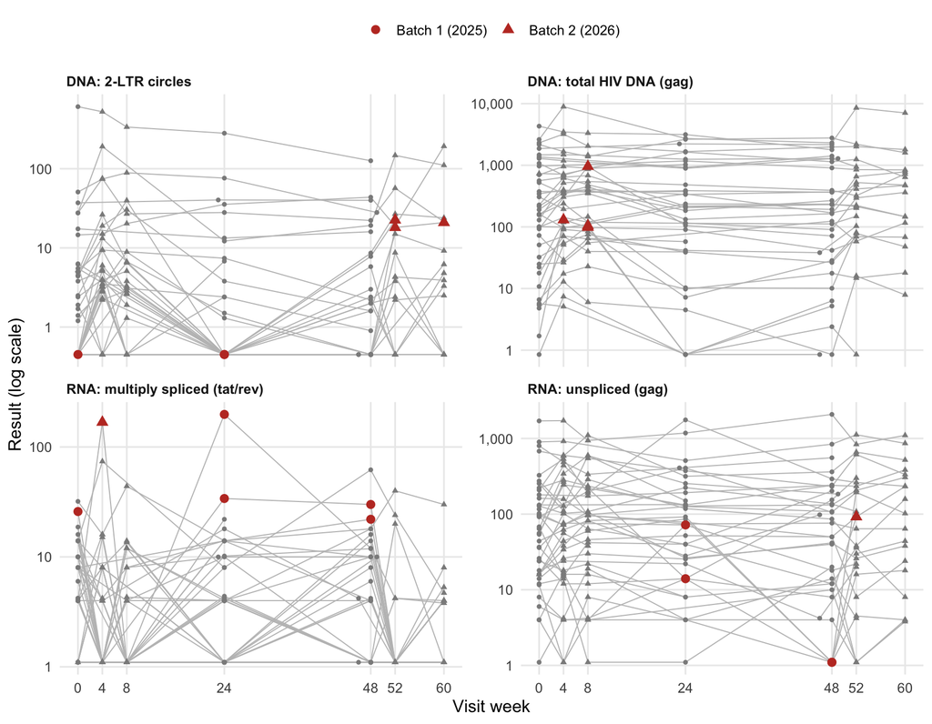

Figure 3: Each grey line is one participant. Red points are flagged results. Shape shows the batch. Log scale.

Table 4. Flagged results (21 in total). The participant’s usual level is the middle (median) of their other results.

| Assay | Participant | Week | Batch | Result | Participant’s usual level | Times higher/lower | Flag |
| --- | --- | --- | --- | --- | --- | --- | --- |
| DNA: 2-LTR circles | 0214820I | 0 | Batch 1 (2025) | not detected | 10.1 | 23× lower | Unusual for participant |
| DNA: 2-LTR circles | 0214820I | 24 | Batch 1 (2025) | not detected | 10.1 | 23× lower | Unusual for participant |
| DNA: 2-LTR circles | 0214820I | 52 | Batch 2 (2026) | 22.5 | 1.87 | 12× higher | Unusual for participant |
| DNA: 2-LTR circles | 0362478J | 52 | Batch 2 (2026) | 18.1 | 0.45 | 40× higher | Unusual for participant |
| DNA: 2-LTR circles | 0362478J | 60 | Batch 2 (2026) | 20.9 | 0.45 | 46× higher | Unusual for participant |
| DNA: 2-LTR circles | 0611487H | 24 | Batch 1 (2025) | not detected | 24 | 53× lower | Unusual for participant |
| DNA: total HIV DNA (gag) | 0014995D | 8 | Batch 2 (2026) | 958 | 92.9 | 10× higher | Unusual for participant |
| DNA: total HIV DNA (gag) | 0146528D | 4 | Batch 2 (2026) | 130 | 1.2 | 108× higher | Unusual for participant |
| DNA: total HIV DNA (gag) | 0146528D | 8 | Batch 2 (2026) | 98.4 | 1.2 | 82× higher | Unusual for participant |
| DNA: total HIV DNA (gag) | 0243764F | 8 | Batch 2 (2026) | 104 | 5.3 | 20× higher | Unusual for participant |
| RNA: multiply spliced (tat/rev) | 0073818G | 48 | Batch 1 (2025) | 22 | 1.1 | 20× higher | Unusual for participant |
| RNA: multiply spliced (tat/rev) | 0141868J | 0 | Batch 1 (2025) | 25.9 | 1.1 | 24× higher | Unusual for participant |
| RNA: multiply spliced (tat/rev) | 0214820I | 24 | Batch 1 (2025) | 34 | 1.1 | 31× higher | Unusual for participant |
| RNA: multiply spliced (tat/rev) | 0214820I | 48 | Batch 1 (2025) | 30 | 1.1 | 27× higher | Unusual for participant |
| RNA: multiply spliced (tat/rev) | 0251731C | 4 | Batch 2 (2026) | 168 | 4.1 | 41× higher | Unusual for participant |
| RNA: multiply spliced (tat/rev) | 0251731C | 24 | Batch 1 (2025) | 198 | 4.1 | 48× higher | Unusual for participant |
| RNA: unspliced (gag) | 0141222D | 52 | Batch 2 (2026) | 92 | 8 | 12× higher | Unusual for participant |
| RNA: unspliced (gag) | 0146526H | 48 | Batch 1 (2025) | not detected | 92 | 84× lower | Unusual for participant |
| RNA: unspliced (gag) | 0214820I | 24 | Batch 1 (2025) | 14 | 215 | 15× lower | Unusual for participant |
| RNA: unspliced (gag) | 0270425K | 48 | Batch 1 (2025) | not detected | 44 | 40× lower | Unusual for participant |
| RNA: unspliced (gag) | 0781484K | 24 | Batch 1 (2025) | 71.9 | 4 | 18× higher | Unusual for participant |